# Practica 1 _ Semana1

## 1.01_StringBasics

```python
# define a new sequence
seq = "ACGT"
```

```python
# Get a character from a string
seq[1]
```

```
'C'
```

```python
# get the length of a sequence
len(seq)
```

```
4
```

```python
# empty string (epsilon)
e = ''
len(e)
```

```
0
```

```python
# concatenation
seq1 = 'AACC'
seq2 = 'GGTT'
print(seq1 + seq2)
```

```
AACCGGTT
```

```python
seqs = ['A', 'C', 'G', 'T']
print(''.join(seqs))
```

```
ACGT
```

```python
# generate a random nucleotide
import random
random.seed(6)
random.choice('ACGT')
```

```
'A'
```

```python
# generate a random sequence
#crear una secuencia vacia
seq = ''
#random.seed(5)
#loop usando +=  , en vez de "_" puede ser "i"
#
for _ in range(10):
    seq += random.choice('ACGT')
print(seq)
```

```
GTCAGCTGGA
```

```python
# another way to generate a random sequence
seq = ''.join([random.choice('ACGT') for _ in range(10)])
print(seq)
```

```
TACAGGAACT
```

```python
# get a substring
seq[1:3]
```

```
'AC'
```

```python
# another way to get a suffix
seq[-3:]
```

```
'ACT'
```

# Practica 2 _ Semana 1

## Manipulating DNA strings

```python
def longestCommonPrefix(s1, s2):
    i = 0
    while i < len(s1) and i < len(s2) and s1[i] == s2[i]:
        i += 1
    return s1[:i]
longestCommonPrefix('ACCATTG', 'ACCAAGTC')
```

```
'ACCA'
```

```python
def match(s1, s2):
    if not len(s1) == len(s2):
        return False
    for i in range(0, len(s1)):
        if not s1[i] == s2[i]:
            return False
    return True
match('ACCATTG', 'ACCATTG')
```

```
True
```

```python
match('ACCATTGC', 'ACCATTG')
```

```
False
```

```python
'ACCATTG' == 'ACCATTG'
```

```
True
```

#### Dictionary

```python
complement = {'A': 'T', 'C': 'G', 'G': 'C', 'T': 'A'}
```

```python
complement['A']
```

```
'T'
```

```python
def reverseComplement(s):
    complement = {'A': 'T', 'C': 'G', 'G': 'C', 'T': 'A'}
    t = ''
    for base in s:
        t = complement[base] +t
    return t
reverseComplement('ACCATTG')
```

```
'CAATGGT'
```

# Practica 3 _ Semana 1

## Downloading and parsing a genome

```python
import os
os.getcwd()
```

```
'/home/joerobles/Documents/AlgritmDnaSeq-master'
```

```python
#!wget http://d28rh4a8wq0iu5.cloudfront.net/ads1/data/lambda_virus.fa
```

[output not shown]

```python
def readGenome(filename):
    genome = ''
    with open(filename, 'r') as f:
        for line in f:
            # ignore header line with genome information
            if not line[0] == '>':
                genome += line.rstrip()
    return genome
genome = readGenome('lambda_virus.fa')
genome[:100]
```

```
'GGGCGGCGACCTCGCGGGTTTTCGCTATTTATGAAAATTTTCCGGTTTAAGGCGTTTCCGTTCTTCTTCGTCATAACTTAATGTTTTTATTTAAAATACC'
```

```python
len(genome)
```

```
48502
```

```python
# Count the number of occurences of each base
# Initialize at cero
counts = {'A': 0, 'C': 0, 'G': 0, 'T': 0}
for base in genome:
    counts[base] += 1
print(counts)
```

```
{'A': 12334, 'C': 11362, 'T': 11986, 'G': 12820}
```

```python
import collections
collections.Counter(genome)
```

```
Counter({'A': 12334, 'C': 11362, 'G': 12820, 'T': 11986})
```

# Practica 4_ Semana 1

## Working with sequencing reads

```python
!wget http://d28rh4a8wq0iu5.cloudfront.net/ads1/data/SRR835775_1.first1000.fastq
```

```
--2018-10-14 18:43:53--  http://d28rh4a8wq0iu5.cloudfront.net/ads1/data/SRR835775_1.first1000.fastq
Resolviendo d28rh4a8wq0iu5.cloudfront.net (d28rh4a8wq0iu5.cloudfront.net)... 52.85.39.104, 52.85.39.72, 52.85.39.22, ...
Conectando con d28rh4a8wq0iu5.cloudfront.net (d28rh4a8wq0iu5.cloudfront.net)[52.85.39.104]:80... conectado.
Petición HTTP enviada, esperando respuesta... 200 OK
Longitud: 224786 (220K) [application/octet-stream]
Grabando a: “SRR835775_1.first1000.fastq”

SRR835775_1.first10 100%[===================>] 219,52K  61,0KB/s    in 3,6s

2018-10-14 18:43:58 (61,0 KB/s) - “SRR835775_1.first1000.fastq” guardado [224786/224786]
```

```python
def readFastq(filename):
    sequences = []
    qualities = []
    with open(filename) as fh:
        while True:
            fh.readline() # skip name line
            seq = fh.readline().rstrip() # read base sequence
            fh.readline() # skip placeholder line
            qual = fh.readline().rstrip() #base quality line
            if len(seq) == 0:
                break
            sequences.append(seq)
            qualities.append(qual)
    return sequences, qualities
seqs, quals = readFastq('SRR835775_1.first1000.fastq')
```

```python
print(seqs[-1:])
```

```
['GTTGGCTGCCCCTGCAGGTCCCTGTCACCTCTCACATGTCCCTGCCTAATCTTGCAGGTCCCAGAGAACTACTTCTATGTGCCAGACCTGGGCCAGGTGC']
```

```python
print(quals[:2])
```

```
['???B1ADDD8??BB+C?B+:AA883CEE8?C3@DDD3)?D2;DC?8?=BAD=@C@(.6.6=A?=?@##################################', 'CCCFFFFFGHHGHJJJJJIJGIIJJJJJJJIJIJJJJJFJJFGIIIIH=CBFCF=CCEG)=>EHB2@@DEC>;;?=;(=?BBD?59?BA###########']
```

```python
def phred33ToQ(qual):
    return ord(qual) - 33
```

```python
phred33ToQ("H")
```

```
39
```

```python
def createHist(qualityStrings):
    # Create a histogram of quality scores
    hist = [0]*50
    for read in qualityStrings:
        for phred in read:
            q = phred33ToQ(phred)
            hist[q] += 1
    return hist
```

```python
h = createHist(quals)
print(h)
```

```
[0, 0, 6178, 0, 0, 54, 108, 574, 345, 83, 193, 124, 79, 165, 49, 236, 184, 327, 514, 238, 531, 254, 313, 798, 992, 888, 1396, 1488, 993, 1752, 3387, 4487, 3248, 5476, 8375, 11814, 4243, 7827, 6579, 8179, 9349, 8180, 0, 0, 0, 0, 0, 0, 0, 0]
```

```python
# Plot the histogram
%matplotlib inline
import matplotlib.pyplot as plt
plt.plot(range(len(h)), h)    #plt.bar  #plt.plot
plt.show()
```

[output not shown]

# Practica 5 _ Semana 1

## Analyzing reads by position

```python
def findGCByPos(reads):
    ''' Find the GC ratio at each position in the read '''
    # Keep track of the number of G/C bases and the total number of bases at each position
    gc = [0] * 100
    totals = [0] * 100
    for read in reads:
        for i in range(len(read)):
            if read[i] == 'C' or read[i] == 'G':
                gc[i] += 1
            totals[i] += 1
    # Divide G/C counts by total counts to get the average at each position
    for i in range(len(gc)):
        if totals[i] > 0:
            gc[i] /= float(totals[i])
    return gc
```

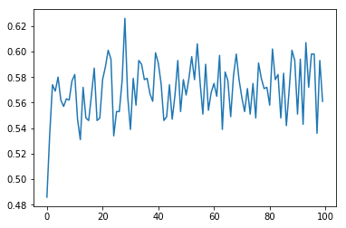

```python
gc = findGCByPos(seqs)
plt.plot(range(len(gc)), gc)
plt.show()
```

```python
import collections
count = collections.Counter()
for seq in seqs:
    count.update(seq)
print(count)
```

```
Counter({'G': 28742, 'C': 28272, 'T': 21836, 'A': 21132, 'N': 18})
```

# Practica 6 _ Semana 1

## Matching artificial reads

```python
!wget http://d28rh4a8wq0iu5.cloudfront.net/ads1/data/phix.fa
```

```
--2017-06-24 11:52:07--  http://d28rh4a8wq0iu5.cloudfront.net/ads1/data/phix.fa
Resolving d28rh4a8wq0iu5.cloudfront.net (d28rh4a8wq0iu5.cloudfront.net)... 52.84.74.29, 52.84.74.208, 52.84.74.248, ...
Connecting to d28rh4a8wq0iu5.cloudfront.net (d28rh4a8wq0iu5.cloudfront.net)|52.84.74.29|:80... connected.
HTTP request sent, awaiting response... 200 OK
Length: 5528 (5,4K) [application/octet-stream]
Saving to: ‘phix.fa’

phix.fa             100%[===================>]   5,40K  --.-KB/s    in 0,001s

2017-06-24 11:52:07 (4,83 MB/s) - ‘phix.fa’ saved [5528/5528]
```

```python
def readGenome(filename):
    genome = ''
    with open(filename, 'r') as f:
        for line in f:
            # ignore header line with genome information
            if not line[0] == '>':
                genome += line.rstrip()
    return genome
```

```python
genome = readGenome('phix.fa')
```

```python
def naive(p, t):
    occurrences = []
    for i in range(len(t) - len(p) + 1):
        match = True
        for j in range(len(p)):
            if t[i+j] != p[j]:
                match = False
                break
        if match:
          occurrences.append(i)
    return occurrences
```

```python
t = 'AGCTTAGATAGC'
p = 'AG'
naive(p, t)
```

```
[0, 5, 9]
```

```python
import random
def generateReads(genome, numReads, readLen):
    ''' Generate reads from random positions in the given genome. '''
    reads = []
    for _ in range(numReads):
        start = random.randint(0, len(genome)-readLen) - 1
        reads.append(genome[start : start+readLen])
    return reads
```

```python
# Generate 100 reads of length 100
reads = generateReads(genome, 100, 100)

# Count how many reads match the genome exactly
numMatched = 0
for r in reads:
    matches = naive(r, genome)
    if len(matches) > 0:
        numMatched += 1
print('%d / %d reads matched the genome exactly!' % (numMatched, len(reads)))
```

```
100 / 100 reads matched the genome exactly!
```

# Practica 7 _ Semana 1

## Matching real reads

```python
def readFastq(filename):
    sequences = []
    qualities = []
    with open(filename) as fh:
        while True:
            fh.readline() # skip name line
            seq = fh.readline().rstrip() # read base sequence
            fh.readline() # skip placeholder line
            qual = fh.readline().rstrip() #base quality line
            if len(seq) == 0:
                break
            sequences.append(seq)
            qualities.append(qual)
    return sequences, qualities
```

```python
phix_reads, _ = readFastq('ERR266411_1.first1000.fastq')
```

```python
phix_reads[0:3]
```

```
['TAAACAAGCAGTAGTAATTCCTGCTTTATCAAGATAATTTTTCGACTCATCAGAAATATCCGAAAGTGTTAACTTCTGCGTCATGGAAGCGATAAAACTC',
 'AACAAGCAGTAGTAATTCCTGCTTTATCAAGATAATTTTTCGACTCATCAGAAATATACGAAAGTGTTAACTTCTGCGTCATGGACACGAAAAAACTCCC',
 'TAAACAAGCAGTAGTAATTCCTGCTTTATCAAGATAATTTTTCGACTCATCAGAAATATCCGAAAGTGTTAACTTCTGCGTCATGGAAGCGATAAAACTC']
```

```python
import collections
count = collections.Counter()
for read in phix_reads:
    count.update(read)
count
```

```
Counter({'A': 28426, 'C': 21890, 'G': 19147, 'N': 6, 'T': 30531})
```

```python
numMatched = 0
n = 0
for r in phix_reads:
    matches = naive(r, genome)
    n += 1
    if len(matches) > 0:
        numMatched += 1
print('%d / %d reads matched the genome exactly!' % (numMatched, n))
```

```
7 / 1000 reads matched the genome exactly!
```

```python
numMatched = 0
n = 0
for r in phix_reads:
    r=r[:30]
    matches = naive(r, genome)
    n += 1
    if len(matches) > 0:
        numMatched += 1
print('%d / %d reads matched the genome exactly!' % (numMatched, n))
```

```
459 / 1000 reads matched the genome exactly!
```

```python
def reverseComplement(s):
    complement = {'A': 'T', 'C': 'G', 'G': 'C', 'T': 'A', 'N': 'N'}
    t = ''
    for base in s:
        t = complement[base] +t
    return t
```

```python
numMatched = 0
n = 0
for r in phix_reads:
    r=r[:30]
    matches = naive(r, genome)
    matches.extend(naive(reverseComplement(r),genome))
    n += 1
    if len(matches) > 0:
        numMatched += 1
print('%d / %d reads matched the genome exactly!' % (numMatched, n))
```

```
932 / 1000 reads matched the genome exactly!
```

# Quiz 1

In lecture and in a practical, we saw an implementation of the naive exact matching algorithm:

```python
def naive(p, t):
    occurrences = []
    for i in range(len(t) - len(p) + 1):  # loop over alignments
        match = True
        for j in range(len(p)):  # loop over characters
            if t[i+j] != p[j]:  # compare characters
                match = False
                break
        if match:
            occurrences.append(i)  # all chars matched; record
    return occurrences
```

...and we saw a function that takes a DNA string and returns its reverse complement:

```python
def reverseComplement(s):
    complement = {'A': 'T', 'C': 'G', 'G': 'C', 'T': 'A', 'N': 'N'}
    t = ''
    for base in s:
        t = complement[base] +t
    return t
```

...and we saw a function that parses a DNA reference genome from a file in the FASTA format.

```python
def readGenome(filename):
    genome = ''
    with open(filename, 'r') as f:
        for line in f:
            # ignore header line with genome information
            if not line[0] == '>':
                genome += line.rstrip()
    return genome
```

...and we saw a function that parses the read and quality strings from a FASTQ file containing sequencing reads.

```python
def readFastq(filename):
    sequences = []
    qualities = []
    with open(filename) as fh:
        while True:
            fh.readline() # skip name line
            seq = fh.readline().rstrip() # read base sequence
            fh.readline() # skip placeholder line
            qual = fh.readline().rstrip() #base quality line
            if len(seq) == 0:
                break
            sequences.append(seq)
            qualities.append(qual)
    return sequences, qualities
```

First, implement a version of the naive exact matching algorithm that is strand-aware. That is, instead of looking only for occurrences of P in T, additionally look for occurrences of the reverse complement of P in T.

If P is ACT, your function should find occurrences of both ACT and its reverse complement AGT in T.

If P and its reverse complement are identical (e.g. AACGTT), then a given match offset should be reported only once. So if your new function is called naive_with_rc, then the old naivefunction and your new naive_with_rc function should return the same results when P equals its reverse complement.

Next, download and parse the lambda virus genome, at: https://d28rh4a8wq0iu5.cloudfront.net/ads1/data/lambda_virus.fa

```python
#crear nueva version
def reverseComplement(s):
    complement = {'A': 'T', 'C': 'G', 'G': 'C', 'T': 'A', 'N': 'N'}
    t = ''
    for base in s:
        t = complement[base] +t
    return t

def naive_with_rc(p, t):
    occurrences = []
    reverseOccurrences = []
    q = reverseComplement(p)

    for i in range(len(t) - len(p) + 1):
        match = True
        matchr = True
        for j in range(len(p)):
            if t[i+j] != p[j]:
                match = False
                break

        for k in range(len(q)):
            if t[i+k] != q[k]:
                matchr = False
                break
        if (match == True) or (matchr ==True):
            occurrences.append(i)

    return occurrences
```

Hint: See this notebook for a few examples you can use to test your naive_with_rc function.

## Ejemplos

```python
# Implement the naive_with_rc function
from naive_with_rc import naive_with_rc
```

### Example 1

```python
p = 'CCC'
ten_as = 'AAAAAAAAAA'
t = ten_as + 'CCC' + ten_as + 'GGG' + ten_as
occurrences = naive_with_rc(p, t)
print(occurrences)
```

```
[10, 23]
```

### Example 2

```python
p = 'CGCG'
t = ten_as + 'CGCG' + ten_as + 'CGCG' + ten_as
occurrences = naive_with_rc(p, t)
print(occurrences)
```

```
[10, 24]
```

### Example 3

```python
# Phi-X genome
# !wget http://d396qusza40orc.cloudfront.net/ads1/data/phix.fa

def readGenome(filename):
    genome = ''
    with open(filename, 'r') as f:
        for line in f:
            # ignore header line with genome information
            if not line[0] == '>':
                genome += line.rstrip()
    return genome
```

```python
phix_genome = readGenome('phix.fa')
```

```python
occurrences = naive_with_rc('ATTA', phix_genome)
```

```python
print('offset of leftmost occurrence: %d' % min(occurrences))
```

```
offset of leftmost occurrence: 62
```

```python
print('# occurrences: %d' % len(occurrences))
```

```
# occurrences: 60
```

```python
print(occurrences)
```

```
[62, 82, 103, 245, 341, 373, 440, 639, 707, 710, 712, 823, 845, 961, 997, 1005, 1084, 1246, 1269, 1336, 1446, 1455, 1576, 1602, 1628, 1722, 2168, 2226, 2329, 2389, 2420, 2540, 2549, 2600, 2752, 2886, 2895, 3083, 3106, 3285, 3313, 3566, 3611, 3781, 3898, 3993, 4017, 4183, 4260, 4307, 4309, 4435, 4437…
```

# Homework 1

```python
!wget https://d28rh4a8wq0iu5.cloudfront.net/ads1/data/lambda_virus.fa
```

```
--2017-06-24 14:54:30--  https://d28rh4a8wq0iu5.cloudfront.net/ads1/data/lambda_virus.fa
Resolving d28rh4a8wq0iu5.cloudfront.net (d28rh4a8wq0iu5.cloudfront.net)... 52.84.74.99, 52.84.74.29, 52.84.74.137, ...
Connecting to d28rh4a8wq0iu5.cloudfront.net (d28rh4a8wq0iu5.cloudfront.net)|52.84.74.99|:443... connected.
HTTP request sent, awaiting response... 200 OK
Length: 49270 (48K) [application/octet-stream]
Saving to: ‘lambda_virus.fa.1’

lambda_virus.fa.1   100%[===================>]  48,12K  --.-KB/s    in 0,1s

2017-06-24 14:54:31 (389 KB/s) - ‘lambda_virus.fa.1’ saved [49270/49270]
```

```python
lambda_genome = readGenome('lambda_virus.fa.1')
```

1. How many times does AGGT or its reverse complement ACCT occur in the lambda virus genome? E.g. if AGGT occurs 10 times and ACCT occurs 12 times, you should report 22.

```python
occurrences = naive_with_rc('AGGT', lambda_genome)
print(len(occurrences))
```

```
306
```

1. How many times does TTAA or its reverse complement occur in the lambda virus genome?

```python
occurrences = naive_with_rc('TTAA', lambda_genome)
print(len(occurrences))
```

```
195
```

1. What is the offset of the leftmost occurrence of ACTAAGT or its reverse complement in the Lambda virus genome? E.g. if the leftmost occurrence of ACTAAGT is at offset 40 (0-based) and the leftmost occurrence of its reverse complement ACTTAGT is at offset 29, then report 29.

```python
occurrences = naive_with_rc('ACTAAGT', lambda_genome)
print('offset of leftmost occurrence: %d' % min(occurrences), occurrences)
```

```
('offset of leftmost occurrence: 26028', [26028, 27733, 45382])
```

1. What is the offset of the leftmost occurrence of AGTCGA or its reverse complement in the Lambda virus genome?

```python
occurrences = naive_with_rc('AGTCGA', lambda_genome)
print('offset of leftmost occurrence: %d' % min(occurrences), occurrences)
```

```
('offset of leftmost occurrence: 450', [450, 1908, 2472, 18005, 23320, 33657, 41927, 44806, 45369])
```

### NUEVA VERSION: naive_2mm

As we will discuss, sometimes we would like to find approximate matches for P in T. That is, we want to find occurrences with one or more differences.

For Questions 5 and 6, make a new version of the naive function called naive_2mm that allows up to 2 mismatches per occurrence. Unlike for the previous questions, do not consider the reverse complement here. We're looking for approximate matches for P itself, not its reverse complement.

For example, ACTTTA occurs twice in ACTTACTTGATAAAGT, once at offset 0 with 2 mismatches, and once at offset 4 with 1 mismatch. So naive_2mm(’ACTTTA’,’ACTTACTTGATAAAGT’) should return the list [ 0 , 4 ].

```python
def naive_2mm(p, t):
    occurrences = []

    for i in range(len(t) - len(p) + 1):
        cross =0
        for j in range(len(p)):
            if t[i+j] != p[j]:
                cross += 1
                match = False

        if cross <= 2:
          occurrences.append(i)
    return occurrences
```

Hint: See this notebook for a few examples you can use to test your naive_2mm function.

## Ejemplos

```python
# Implement the naive_2mm function
from naive_2mm import naive_2mm
```

### Ejemplo 1

```python
p = 'CTGT'
ten_as = 'AAAAAAAAAA'
t = ten_as + 'CTGT' + ten_as + 'CTTT' + ten_as + 'CGGG' + ten_as
occurrences = naive_2mm(p, t)
print(occurrences)
```

```
[10, 24, 38]
```

### Ejemplo 2

```python
# Phi-X genome
!wget http://d396qusza40orc.cloudfront.net/ads1/data/phix.fa
```

```python
def readGenome(filename):
    genome = ''
    with open(filename, 'r') as f:
        for line in f:
            # ignore header line with genome information
            if not line[0] == '>':
                genome += line.rstrip()
    return genome
```

```python
phix_genome = readGenome('phix.fa')
```

```python
occurrences = naive_2mm('GATTACA', phix_genome)
```

```python
print('offset of leftmost occurrence: %d' % min(occurrences))
```

```
offset of leftmost occurrence: 10
```

```python
print('# occurrences: %d' % len(occurrences))
```

```
# occurrences: 79
```

```python
p = 'ACTTTA'
t = 'ACTTACTTGATAAAGT'
occurrences = naive_2mm(p, t)
print(occurrences)
```

```
[0, 4]
```

1. How many times does TTCAAGCC occur in the Lambda virus genome when allowing up to 2 mismatches?

```python
occurrences = naive_2mm('TTCAAGCC', lambda_genome)
print(len(occurrences))
```

```
191
```

1. What is the offset of the leftmost occurrence of AGGAGGTT in the Lambda virus genome when allowing up to 2 mismatches?

```python
occurrences = naive_2mm('AGGAGGTT', lambda_genome)
print('offset of leftmost occurrence: %d' % min(occurrences))
```

```
offset of leftmost occurrence: 49
```

Finally, download and parse the provided FASTQ file containing real DNA sequencing reads derived from a human:

https://d28rh4a8wq0iu5.cloudfront.net/ads1/data/ERR037900_1.first1000.fastq

Note that the file has many reads in it and you should examine all of them together when answering this question.

This dataset has something wrong with it; one of the sequencing cycles is poor quality.

1. Report which sequencing cycle has the problem. Remember that a sequencing cycle corresponds to a particular offset in all the reads. For example, if the leftmost read position seems to have a problem consistently across reads, report 0. If the fourth position from the left has the problem, report 3. Do whatever analysis you think is needed to identify the bad cycle. It might help to review the "Analyzing reads by position" video.

```python
!wget https://d28rh4a8wq0iu5.cloudfront.net/ads1/data/ERR037900_1.first1000.fastq
```

```
--2018-10-14 12:57:18--  https://d28rh4a8wq0iu5.cloudfront.net/ads1/data/ERR037900_1.first1000.fastq
Resolviendo d28rh4a8wq0iu5.cloudfront.net (d28rh4a8wq0iu5.cloudfront.net)... 13.32.81.156, 13.32.81.77, 13.32.81.9, ...
Conectando con d28rh4a8wq0iu5.cloudfront.net (d28rh4a8wq0iu5.cloudfront.net)[13.32.81.156]:443... conectado.
Petición HTTP enviada, esperando respuesta... 200 OK
Longitud: 241626 (236K) [application/octet-stream]
Grabando a: “ERR037900_1.first1000.fastq.2”

        ERR037900_1  23%[===>                ]  55,43K  21,6KB/s               ^C
```

```python
def readFastq(filename):
    sequences = []
    qualities = []
    with open(filename) as fh:
        while True:
            fh.readline() # skip name line
            seq = fh.readline().rstrip() # read base sequence
            fh.readline() # skip placeholder line
            qual = fh.readline().rstrip() #base quality line
            if len(seq) == 0:
                break
            sequences.append(seq)
            qualities.append(qual)
    return sequences, qualities
```

```python
seq, qual = readFastq("ERR037900_1.first1000.fastq")
```

```python
# primero hacer prueba con un read, el primero
```

```python
qu=qual[:1]

print(qu)
```

```
['HHHHHHHHHHHHHHHHHHHHHHHHHHHHHHHHHHHHHHHHHHHGFHHHFHFFHHHHHGHHFHEH@4#55554455HGFBF<@C>7EEF@FBEDDD<=C<E']
```

```python
def phred33ToQ(qual):
    return ord(qual) - 33
```

```python
def listaQuality(readQual):
    for read in readQual:
        gc = []
        for c in read:
            h = phred33ToQ(c)
            gc.append(h)
    return gc
```

```python
list = listaQuality(qu)
print(list)
```

```
[39, 39, 39, 39, 39, 39, 39, 39, 39, 39, 39, 39, 39, 39, 39, 39, 39, 39, 39, 39, 39, 39, 39, 39, 39, 39, 39, 39, 39, 39, 39, 39, 39, 39, 39, 39, 39, 39, 39, 39, 39, 39, 39, 38, 37, 39, 39, 39, 37, 39, 37, 37, 39, 39, 39, 39, 39, 38, 39, 39, 37, 39, 36, 39, 31, 19, 2, 20, 20, 20, 20, 19, 19, 20, 20, …
```

```python
# sudo -H pip3 install --upgrade --default-timeout=100 matplotlib
```

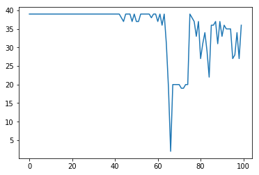

```python
# Plot the histogram
%matplotlib inline
import matplotlib.pyplot as plt
plt.plot(range(len(list)), list)
plt.show()
```

```python
list.index(min(list))
```

```
66
```

```python
# ya se tiene la respuesta, pero igual calcular para todos los reads
```

```python
from __future__ import division
def mean(a):
    return sum(a) / len(a)

def listaQuality2(readQual):
    final=[]
    for read in readQual:
        gc = []
        for c in read:
            h = phred33ToQ(c)
            gc.append(h)    #lista
        final.append(gc)     #lista de listas
    #antes el resultado era "final" , ahora es el promedio de listas
    q = list(map(mean, zip(*final)))        #en python2 era sin list, reiniciar si no corre
    return q
```

```python
#explicacion
from __future__ import division
def mean(a):
    return sum(a) / len(a)
b =  [[240, 240, 239],
      [250, 249, 237],
      [242, 239, 237],
      [240, 234, 233]]
```

```python
del list
list(zip(*b))
#map(mean, zip(*b))   #en python2 era sin list, reiniciar o usar "del list" si no corre
```

```
[(240, 250, 242, 240), (240, 249, 239, 234), (239, 237, 237, 233)]
```

```python
mlist= listaQuality2(qual)
print(mlist)
```

```
[38.435, 38.46, 38.4, 38.428, 38.417, 38.382, 38.362, 38.364, 38.325, 38.343, 38.194, 38.154, 38.089, 38.152, 38.153, 38.099, 38.055, 38.041, 38.067, 38.15, 38.087, 37.989, 38.009, 37.909, 38.028, 37.576, 37.514, 37.503, 37.578, 37.552, 37.629, 37.555, 37.548, 37.433, 37.402, 37.343, 37.198, 37.126,…
```

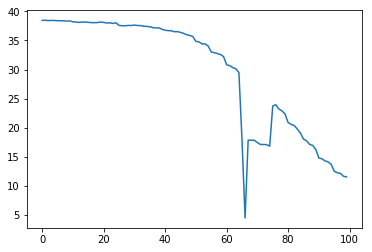

```python
# Plot the histogram
%matplotlib inline
import matplotlib.pyplot as plt
plt.plot(range(len(mlist)), mlist)
plt.show()
```

```python
mlist.index(min(mlist))
```

```
66
```

```python
# Respuesta alternativa
```

```python
def opcional(readQual):
    final=[0]*len(readQual[1])
    for read in readQual:
        gc = []
        for c in read:
            h = phred33ToQ(c)
            gc.append(h)    #lista
        for i in range(len(read)):
            final[i] += gc[i]
    #antes el resultado era "final" , ahora es el promedio de listas
    for i in range(len(final)):
        final[i] /= len(readQual)
    return final
```

```python
mlist2= opcional(qual)
print(mlist2)
```

```
[38.435, 38.46, 38.4, 38.428, 38.417, 38.382, 38.362, 38.364, 38.325, 38.343, 38.194, 38.154, 38.089, 38.152, 38.153, 38.099, 38.055, 38.041, 38.067, 38.15, 38.087, 37.989, 38.009, 37.909, 38.028, 37.576, 37.514, 37.503, 37.578, 37.552, 37.629, 37.555, 37.548, 37.433, 37.402, 37.343, 37.198, 37.126,…
```

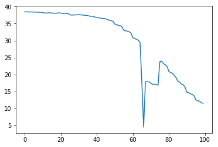

```python
# Plot the histogram
%matplotlib inline
import matplotlib.pyplot as plt
plt.plot(range(len(mlist2)), mlist2)
plt.show()
```

```python
mlist.index(min(mlist2))
```

```
66
```

```python
import bisect
import sys
class Index(object):
    def __init__(self, t, k):
        ''' Create index from all substrings of size 'length' '''
        self.k = k  # k-mer length (k)
        self.index = []
        for i in range(len(t) - k + 1):  # for each k-mer
            self.index.append((t[i:i+k], i))  # add (k-mer, offset) pair
        self.index.sort()  # alphabetize by k-mer

    def query(self, p):
        ''' Return index hits for first k-mer of P '''
        kmer = p[:self.k]  # query with first k-mer
        i = bisect.bisect_left(self.index, (kmer, -1))  # binary search
        hits = []
        while i < len(self.index):  # collect matching index entries
            if self.index[i][0] != kmer:
                break
            hits.append(self.index[i][1])
            i += 1
        return hits
```

```python
def readGenome(filename):
    genome = ''
    with open(filename, 'r') as f:
        for line in f:
            # ignore header line with genome information
            if not line[0] == '>':
                genome += line.rstrip()
    return genome
genome = readGenome('chr1.GRCh38.excerpt.fasta')

t = genome
p_idx = Index(t, 3)
```

```python
int(round(24 / (2+1)))
```

```
8
```

```python
p = 'GGCGCGGTGGCTCACGCCTGTAAT'
p_idx.query(p[0:8])  #169,179,265,408,428,488
```

```python
#169-8+0, 169-8+1, 169-8+2, 169-8+3
for j in range(0, 8):
    print(j)
```

```
0
1
2
3
4
5
6
7
```

```python
#169-0+8 , 169-0+9, 169-0+10, 169-0+11
for j in range(8, 24):
    print(j)
```

```
8
9
10
11
12
13
14
15
16
17
18
19
20
21
22
23
```

```python
def IndexApproximate_match(p, t, n): # n es numero de mismatches
    segment_length = int(round(len(p) / (n+1))) #para p=24 y n=2 es 3
    all_matches = set()
    p_idx = Index(t, segment_length)    #adicionado
    idx_hits = 0        #adicionado
    for i in range(n+1):  #loop over partitions #para n=2 es 0,1,2
        start = i*segment_length                 # 0*8, 1*8, 2*8
        end = min((i+1)*segment_length, len(p))  # 1*8, 2*8, 3*8
        matches = p_idx.query(p[start:end])   #usando Index y ya no boyermoore

        # Extend matching segments to see if whole p matches
        for m in matches:
            idx_hits += 1
            if m < start or m-start+len(p) > len(t):
                continue

            mismatches = 0

            for j in range(0, start):     #verificar hacia la izquierda
                if not p[j] == t[m-start+j]:
                    mismatches += 1
                    if mismatches > n:
                        break
            for j in range(end, len(p)):   #verificar hacia la derecha
                if not p[j] == t[m-start+j]:
                    mismatches += 1
                    if mismatches > n:
                        break

            if mismatches <= n:
                all_matches.add(m - start)
    return list(all_matches), idx_hits
```